# 11 ggplot 2: Scales, guides, faceting, coordinates and themes

In the previous chapter, Chapter 10, we covered the various geometries. We now turn to th appearance and layout of the plot. The appearance refers to the scales including guides, facets and coordinate systems of the grammar of graphics (Chapter 9). The layout components to the non-data parts. Scales are important in data visualization because they determine the visual appearance of your plot. Doing so, they should help the reader with the interpretation of your data visualization. You do so using colors and shapes, transformations of the variables on the x- or y-axis that determine you see the data, or selecting the range of these axis. In addition, you can specify labels or breaks for the axis or titles and labels for the guides. Because these can also abused to mislead people, being aware of the possibilities that these scales offer and how they help to (mis-) inform people is important. There are several guides that might help you selecting axis, grids, … For instance the UK’s Office for national statistics had a full guide on [axis] (https://service-manual.ons.gov.uk/data-visualisation/guidance/axes-and-gridlines) and [colors] (https://service-manual.ons.gov.uk/data-visualisation/colours/using-colours-in-charts). Facets split the plot into subplots, for instance, to show the relation between two variables per value of a third variable. We wil discuss coordinate systems, but do so only briefly. The non-data parts end this chapter.

Scales including guides, facets, coordinate systems and themes each add a layer to the plot.

Before we start, we need to load some packages

and import some data:

```r
life_df <- readr::read_csv(here::here("data", "raw", "life_df.csv"), show_col_types = FALSE)
data_beveridge <- read_csv(here::here("data", "raw", "data_beveridge.csv"))
data_beveridge <- data_beveridge |> rename(date = DATE, quarter = `TIME PERIOD`)
```

## 11.1 Scales

In the previous section, we focused on the geometries and hardly touched upon the scales of e.g. the way in which the x- or y-axis where shown, the choice of the color of a line, size or fill aesthetics. In this section we will take a closer look at this component of the grammar of graphics. Scales determine the details of how data values are translated to visual properties: the type of color used to fill a bar, the way in which the x- and y-axis are set up (log scale, major and minor grid lines, label, …). If you looked at the code for the graph with life expectancy, you saw some lines such as

```r
scale_x_continuous(
 transform = "log",
 breaks = c(100, 1000, 10000, 100000),
 labels = scales::label_currency(prefix = "$")) +
```

or

```r
scale_colour_paletteer_c("grDevices::Purple-Green")
```

These were two lines that change the scale of an aesthetic. The first changes the x-axis and the second changes the color used to show different values of life expectancy. In general the scale functions have a similar format: `scale_{aesthetic}_{continuous/discrete}`. The word ‘scale’ is almost always part of the function. It refers to the scales component of the grammar of graphics. The `{aesthetic}` part refers to the aesthetic: x, y, color, fill, linewidth, alpha, size, shape. Scales can be continuous or discrete. Not all aesthetics are suitable for continuous variables. For instance, there are only so much shapes as there are available in R. In addition, for some scale, there is also a `manual` variant. There are also some specific scales, e.g. for data/time variables, and scales to develop specific color palettes. Here, we will start with the continuous scales, we will then cover the discrete scales and end with the manual scales. In addition to the {ggplot2} scale functions, the {scales} package adds further possibilities. If you use that package, we’ll do so using `scales::`. In that way, it is clear what part of the code is {ggplot2} and what part of {scales}.

Some scale functions are identical: `scale_x_continuous()` and `scale_y_continuous()` or `scale_x_discrete()` and `scale_y_discrete()` are identical, the same holds for e.g. `scale_color_manual()`, `scale_fill_manual()`, `scale_shape_manual()`, `scale_size_manual()`, `scale_linewidth_manual()` and `scale_linetype_manual()`. All these scales allow you to set the values for the aesthetic. They only differ in terms of the way to identify that aesthetic: a shape number, a color or size. In other words, although there are many scale functions, a lot of them share many similarities. The fact that you have so many of them is e.g. due to the fact that for each continuous numeric scale, you have an identical x and y scale, for each color scale, you have a discrete, continuous and manual scale.

### 11.1.1 Continuous scales

We first start with numeric scales. Usually, these are for the x- and y-axis. The scales for the horizontal and vertical axis are position scales: they show a individual value will be mapped on the axis. Other aesthetics that include continuous values are e.g. color, fill or size. For color or fill, you have diverging scales, where colors change from e.g. green to red or from blue to yellow and sequential scales (various shades of e.g. green). We first start with the continuous numeric scales, we then move on to the other scales. We’ll discuss the first scale in detail. For other scales, we’ll only highlight arguments that are specific for these scales.

#### 11.1.1.1 Position scales: `scale_x_continuous()` and `scale_y_continuous()`

Position scales show the position of a value on the horizontal and vertical axis. In other words, they determine where you have to look to find the values and how these values will be shown. In {ggplot2} `scale_x_continuous` and `scale_y_continuous` are function to set the characteristics of the scales of the x- and y-axis. The reference to `continuous` implies that these scales are used for continuous data. Because both these function are identical, we will discuss only one, `scale_x_continuous()`. The arguments of this function - i.e. the scale parameters that you can adjust - are

```r
scale_x_continuous(
  name = waiver(),
  breaks = waiver(),
  minor_breaks = waiver(),
  n.breaks = NULL,
  labels = waiver(),
  limits = NULL,
  expand = waiver(),
  oob = censor,
  na.value = NA_real_,
  transform = "identity",
  trans = deprecated(),
  guide = waiver(),
  position = "bottom",
  sec.axis = waiver()
)
```

We’ll use Figure 11.1 to illustrate these arguments.

Figure 11.1: Scales

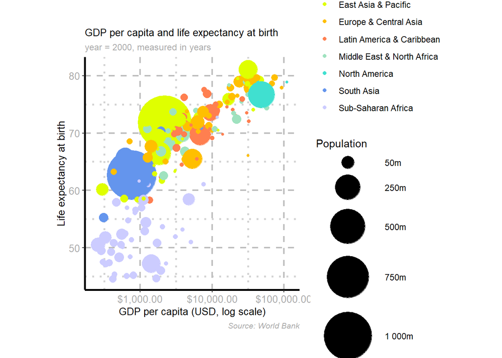

The values for the arguments in the `scale_x_continous()` function that were used in Figure 11.1 are:

```r
scale_x_continuous(
    name = "GDP per capita (USD, log scale)",
    transform = "log",
    breaks = c(100, 1000, 10000, 100000),
    labels = scales::label_currency(prefix = "$")) +
```

For all other arguments, de default values were used.

##### 11.1.1.1.1 The title of the axis:

By default, the `name` of the scale is taken from the aesthetic. For `scale_x_continuous()` that is the variable mapped on the x-axis. In other words, by default, `ggplot()` uses the name of the variable in the data set to add as a label to the axis. If you add a `name = "your_name"`, this name will be shown as the title on the axis. In Figure 11.1, the name of the title was changed from the default value “gdp_capita” (the name in the data frame) into “GDP per capita (USD, log scale)”. You can set these names also using the `labs()` function (which will be introduced below). Using `labs(x = "name of x")` for instance will use “name of x” as the title for the x-axis. Is you set this to NULL in `scale_x_continuous`, the name will dropped, even if you specify a name in the `labs(x= "name of x")` function. You can drop these titles via `labs()` using `labs(x = "")`. In Figure 11.1, for `scale_x_continious()` that means that “GDP per capita (USD, log scale)” would not be shown on the plot. For `scale_y_continuous()` setting `names = NULL` would drop the name (the name of the variable or the name given using `labs()` from the y-axis). We’ll meet this function for other `scale_*_x()` functions as well. For most of these, the variables mapped on the `*` scale (e.g. color, fill or size) are shown in the legend. Setting `name = "name of aesthetic"` adds the “name of aesthetic” to the legend. Using `name = NULL` drops the title from the legend, but not the legend itself. In Figure 11.1, the names for the color and size aesthetic are “Region” and “Population”. Here too, you can set those using the `labs()` function e.g. `labs(color = "Region", size = "Population")` adds both titles to the legend. Using `labs(color = "", size = "")` would remove these titles.

##### 11.1.1.1.2 Breaks and labels

Major and minor breaks are (if shown) shown as vertical (breaks on the x-axis) or horizontal (breaks on the y-axis) lines on the plot. For major breaks, you can add labels. These labels show the value associated with the major breaks.

The `breaks` and `minor_breaks` sets the major and minor breaks for the axis. In Figure 11.1, the major breaks are 1.000, 10.000 and 100.000 on the x-axis and 50, 60, 70 and 80 on the y-axis. If you specify in the `themes()` function that R needs to add major grid lines, R will do so in line with the major breaks and will add minor grid lines in line with the minor breaks. In Figure 11.1, the major grid lines are shown with dashed grey lines; the minor grid lines with dotted grey lines. The default values for both are `waiver()` and allow R to determine both breaks from the data. By default, R adds one minor break point between each of the major breakpoints. Changing `waiver()` into NULL, will remove all major and/or minor break points. A third option allows you to set your own breakpoints using a vector such as `c(1000, 10000, 100000)` or a function that generates these breakpoints e.g. `seq(from = x, to = y, by = z)`. The {scales} packages allows you to set the number of major breaks for the most often used cases:

- `scales::breaks_extended(n = ...)` with `n` the number of major breaks,
- `scales::breaks_width(width, offset = 0)` with `width` the width between major breaks and `offset` if you don’t want breaks to start at e.g. 0 but at e.g. -2 (`offset = -2`)
- `scales::breaks_log(n = 5, base = 10)` to set nice breaks for log-axis with log base `base` (as integer powers of base),

For minor breaks, {scales} includes `minor_breaks_width()` and `minor_breaks_n()`. Using `scale_x_continuous()`, you can set the number of breaks also using `n.breaks =`. However, this is only possible if `breaks` equals its default `waiver()`.

You can add labels to major breaks. In Figure 11.1, these labels are “50”, “60”, “70,”80” on the vertical axis and “$1,000.00”, “$10.000,00” and “$100.000,00” on the horizontal axis. By default, `ggplot()` will add the labels from the data. With `labels = NULL`, you remove the labels. A third options is to add a vector with labels. As there is one label per major break, this vector should have the same length as the number of breaks. You can also add a function, e.g. `paste0`, `paste`, … . Here the function needs to output the same number of labels as there are major breaks. For instance using

```r
paste("$", seq(from = 10000, to = 70000, by = 10000), sep = "")
```

```
[1] "$10000" "$20000" "$30000" "$40000" "$50000" "$60000" "$70000"
```

for labels and

```r
seq(from = 10000, to = 70000, by = 10000)
```

```
[1] 10000 20000 30000 40000 50000 60000 70000
```

for breaks with set major breaks at 10000, 20000, … 70000 and add labels $10000, $20000, … $70000.

As with breaks, {scales} includes a number of ways to deal with labels. This package includes, e.g.

- `scales::label_number()` to show numbers as numbers and not in scientific format. You can define the rounding (`accuracy`), scale factor to use for multiplication before the label is added (e.g. if you want to show values in 1,000,000 of e.g. the population of a country, use a scaling factor 1/1,000,000 will divide all values by 1,000,000 and show these as a label), a suffix or prefix, a decimal and thousands mark, details to show positive and negative values (e.g. with a + and -, a minus for negative values, nothing for positive, parenthesis of a unicode figure space or minus sign)
- `scales::label_currency()` generate labels include a currency prefix or suffix, including the option to set the decimal and thousand mark and a scaling factor that will be used to multiple the values before adding the label (e.g. with scaling factor x = 1/1000, values are in thousands of currency, e.g. the value €25.000 is shown as €25)
- `scales::label_percent()` with the optional scaling factor, which is by default 100 (if percentages in the dataset are 0.01, they will be multiplied with 100 to add as label), a prefix of suffix and decimal and thousands mark,
- `scales::label_scientific()` to show labels using scientific notation (e.g. 10e02, 5e-04),
- `scales::label_ordinal()` allowing you to add a suffix or prefix, e.g. 2nd, 3th with rules defined by default for `ordinal_english()` but optional also available for `ordinal_french(gender = c("masculine", "feminine"), plural = FALSE)` and `ordinal_spanish()`

Before we continue with the other options, let’s see what these options do. To illustrate, we’ll use the diamonds dataset, filter the observations with `carat <= 3` and take a sample of 20% of these observations. Mapping `price` on the vertical axis and `carat` on the horizontal axis and using lightsteelblue as a setting the for color of the dots: the base graph looks like:

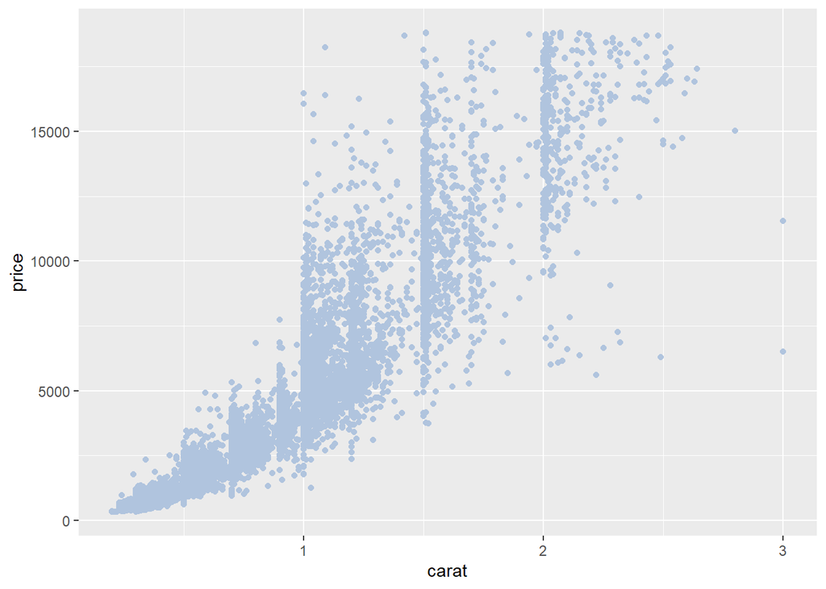

```r
pl_scale_base <- diamonds |> filter(carat <= 3) |>  slice_sample(prop = 0.20) |>
  ggplot(aes(x = carat, y = price)) +
  geom_point(color = "lightsteelblue")

pl_scale_base
```

We will use both `scale_x_continuous` and `scale_y_continuous` to change the plot. Doing so, we can show multiple options in one plot. Let’s change the number of breaks on the horizontal axis using a function and include breaks starting at 0, ending at 3 but in steps of 0.5 (and not steps of 1). For the y-axis, we’ll use a vector with 4 values and include breaks for the vertical axis at 0, 5000, 10000 and 15000 (the same values as the default). We will also change the name of the vertical axis and add a reference to USD in the label of the axis.

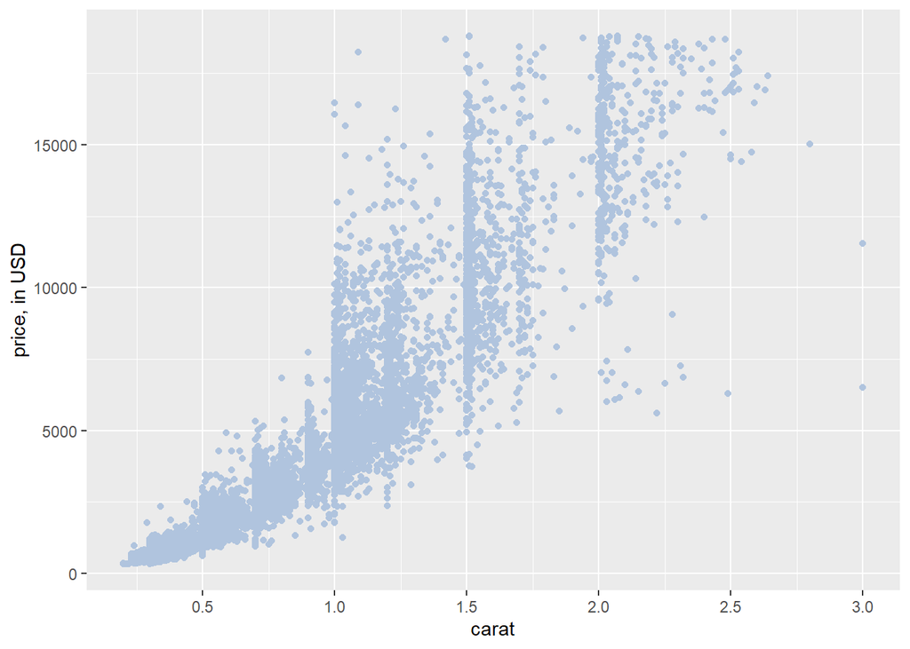

```r
pl_scale_base +
  scale_x_continuous(breaks = seq(from = 0, to = 3, by  = 0.5)) +
  scale_y_continuous(
    name = "price, in USD",
    breaks = c(0, 5000, 10000, 15000))
```

Notice how `ggplot()` also adjusted the minor breaks and adds one in the middle of the major breaks. Let’s remove the minor breaks from the horizontal axis and add minor breaks every 1000 USD on the vertical axis, but only between 5000 and 15000. Starting from the base plot:

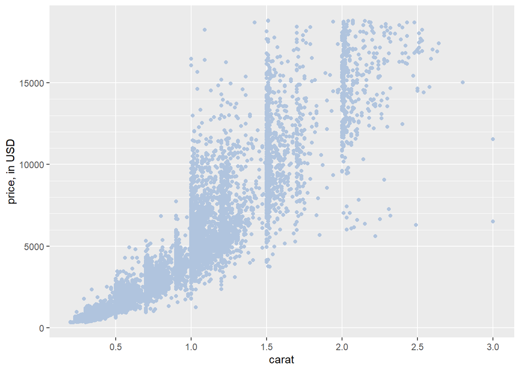

```r
pl_scale_base +
  scale_x_continuous(
    breaks = seq(from = 0, to = 3, by  = 0.5),
    minor_breaks = NULL) +
  scale_y_continuous(
    name = "price, in USD",
    breaks = c(0, 5000, 10000, 15000),
    minor_breaks = seq(5000, 15000, by = 1000))
```

Using {scales} we can set the width of the breaks on the horizontal axis equal to 0.25 and set the number of breaks equal to 10 on the vertical axis:

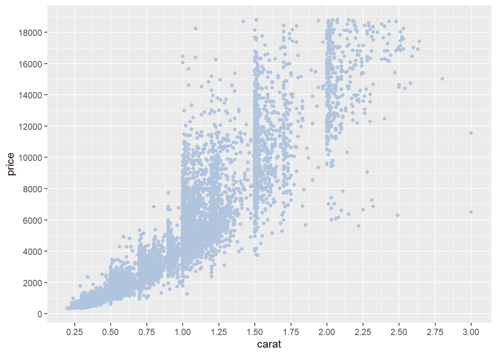

```r
pl_scale_base +
  scale_x_continuous(breaks = scales::breaks_width(0.25)) +
  scale_y_continuous(breaks = scales::breaks_extended(n = 10))
```

To keep the default number of major breaks for the x-axis but change the number of minor breaks on that axis to 15:

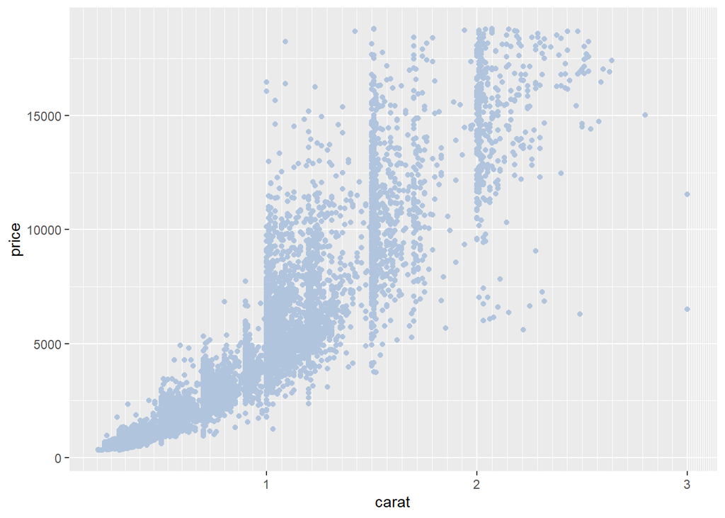

```r
pl_scale_base +
  scale_x_continuous(minor_breaks = scales::minor_breaks_n(n = 15))
```

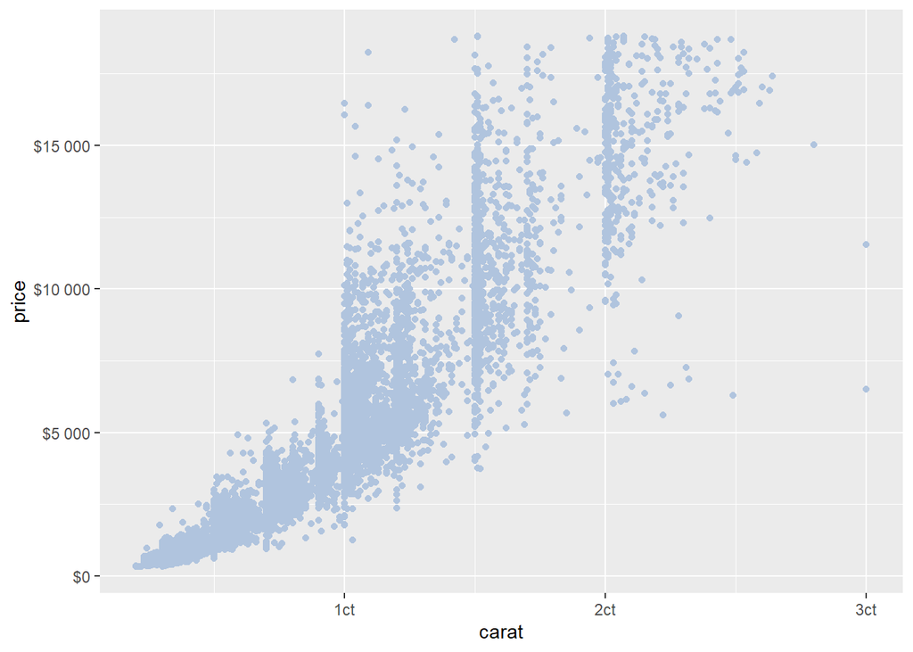

```r
pl_scale_base +
  scale_x_continuous(
    breaks = seq(0, 3, by = 1),
    labels = paste(seq(0, 3, by = 1), "ct", sep = "")) +
  scale_y_continuous(
    breaks = c(0, 5000, 10000, 15000),
    labels = paste0("$", c("0", "5 000", "10 000", "15 000")))
```

Let’s now use {scales}

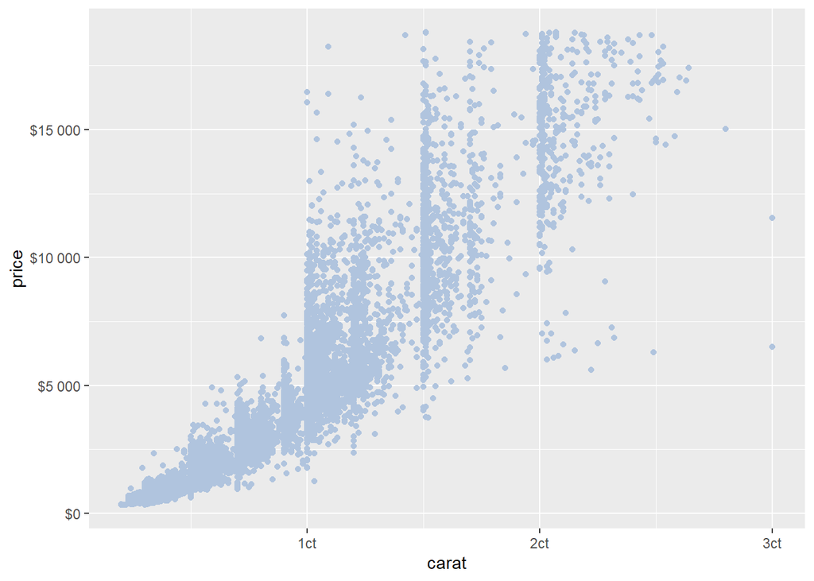

```r
pl_scale_base +
  scale_x_continuous(
    breaks = scales::breaks_extended(n = 3),
    labels = scales::label_number(suffix = "ct")) +
  scale_y_continuous(
    breaks = scales::breaks_width(5000),
    labels = scales::label_currency(
      prefix = "$",
      big.mark = " "))
```

Note that using {scales} the number of labels automatically adjusts to the number of major breaks.

The {scales} functions includes other options. For instance, you can scale the values on the axis. To illustrate, suppose that you want to show the price in euro and not in dollar. The first option would be to crate a euro price in the dataset and plot that euro price. {scales} allows to avoid that step. Suppose for instance that the euro-dollar exchange rate is EUR 1 = USD 1.10. Using this as the scale factor in `scales::label_currency(scale = 1/1.10, ...)` to divide the USD prices and adding a a euro sign as a prefix, will show the dollar prices in euro. Second, to show carat in mg (1ct = 200mg) and add mg, you would scale the carat values with 200 and add “mg” as a suffix to the label. We’ll also add a space for the thousands separator and a dot for the decimal mark on the vertical axis:

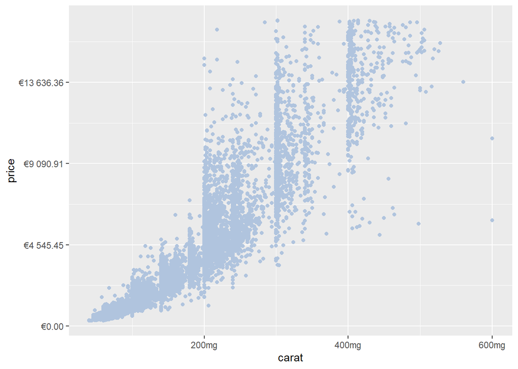

```r
pl_scale_base +
  scale_x_continuous(
    labels = scales::label_number(
      scale = 200,
      suffix = "mg")) +
  scale_y_continuous(
    labels = scales::label_currency(
      scale = 1/1.10,
      prefix = "€",
      big.mark = " ",
      decimal.mark = "."))
```

Note that R shows does not adjust the breaks on the vertical axis: R shows breaks at 5000, 10000 and 15000 but rescaled to euro values. To adjust these labels, we need to adjust the breaks as well. Because we divide the labels, we multiply the breaks:

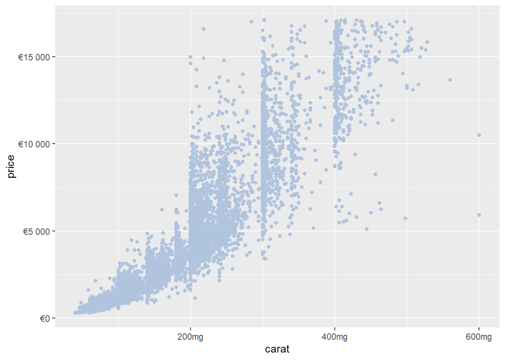

```r
pl_scale_base +
  scale_x_continuous(
    labels = scales::label_number(
      scale = 200,
      suffix = "mg")) +
  scale_y_continuous(
    breaks = seq(0, 15000 * 1.10, by = 5000 * 1.10),
    labels = scales::label_currency(
      scale = 1/1.10,
      prefix = "€",
      big.mark = " ",
      decimal.mark = "."))
```

##### 11.1.1.1.3 Setting a ranges

`expand = waiver()` allows you to add some space between the data and the axis. By default, R expands the scale by 5% for continuous variables and 0.6 units on each side for discrete variables. If you revisit the basic plot in `pl_scale_base`, you can see that R added some space to the right of the value 3 for carat, or on top of the maximum value for price. Using `expansion(mult = 0, add = 0)` you can change these values. If you supply a vector with two values for `mult`, R will add more space equal the the first component on the lower limit and equal to the second component of that vector to the upper limit. If you include one value, R adds space to equal to that value on both sides. Similarly, for `add`, adding two values in a vector allows you to add space on both sides, with one value, that value if used to add the same space on both sides. To illustrate, let’s add 1 unit of space on the lower end of the horizontal axis and 2 on the upper end. Here, one unit is 1 carat. We’ll expand the vertical axis with 15% on the lower end and 25% on the upper end:

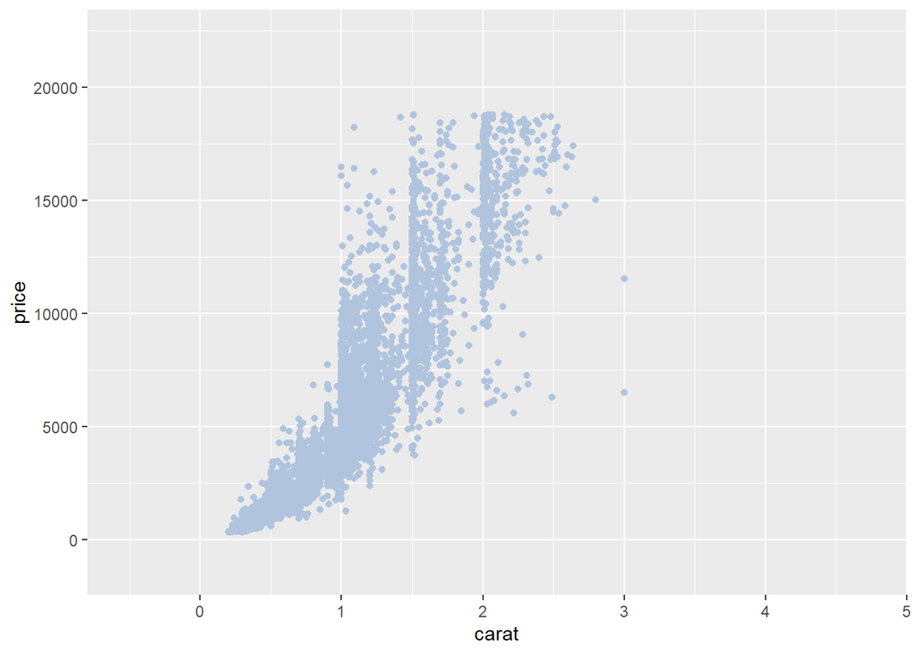

```r
pl_scale_base +
  scale_x_continuous(expand = expansion(add = c(1, 2))) +
  scale_y_continuous(expand = expansion(mult = c(0.15, 0.25)))
```

Note that this does not affect the values that are shown on the plot. The area to the right of 3 on the horizontal axis does not include any carat-price pairs. The same holds for the area above 20000 on the vertical axis or below 0 on both the vertical and horizontal axis.

The arguments `limits = NULL`, `oob = censor` and `na.value = NA_real_` deal with the value and the range of the values shown on the axis. You may want to limit the range shown to exclude e.g. major outliers or to focus on a specific value range. There are multiple ways to reduce the range of values shown. However, they all have different implications for how the other geometries in the plot. The first using the `coord_cartesian()` function from `ggplot()`. We will cover that function more in depth, but it allows you to set the range shown on a plot using e.g. `xlim = c()` for the limits on the x-axis of `ylim` for the range on the y-axis. The vector `c()` includes the minimum value and the maximum value.

Using `limits` you can set the range of values shown on a axis. By default (NULL), `ggplot()` shows all the values in the range. Adding a vector with limits, reduces the range of the axis to the limits in the vector. You can also specify a function that returns an upper and a lower value for the range. The question is what happens to the values outside of the range? This might be relevant is your add a `geom_smooth()` or a vertical or horizontal line showing the mean of median value for a variable on one of the axis. Values that are out of the range are also referred to as out of bonds. What happens to these out of bound values is what `oob` (out of bounds) determines. By default, `censor` sets all the out of bounds (oob) values to `NA`. You can change that using {scales} to `squish` which replaces out of bounds values with their nearest range limit and `keep` which keeps the values. The way in which you handle out of bounds values in case you set limits on the range has important implications for other geoms. Using the default `censor` R sets these values to `NA` for the plot. R does so before the plot is drawn. Any other geometry will not be able to access these values. For instance, `geom_smooth()` will only be able to smooth data that is not missing, i.e. data that is within the limits of the range. Using `keep` avoids this. There is another alternative: you can set the limits in the coordinate component of the grammar. Doing so, R keeps the values of the out or bounds values as they are. Setting limits in the coordinate component zooms in on the data. To see the difference, let’s set limits on the data range to 0.5 - 2.5 on the carat variable. We’ll do so withing the `scale_x_continuous` function using `limits = c(0.5, 2.5)`. We’ll also use the default value for the out of bounds values: `censor` and create a second plot with the `keep` option from {scales}. Third, we’ll set the range in the coordinate. Here, we use `xlim = c(0.5, 2.5)`. The final plot uses all values in the dataset.

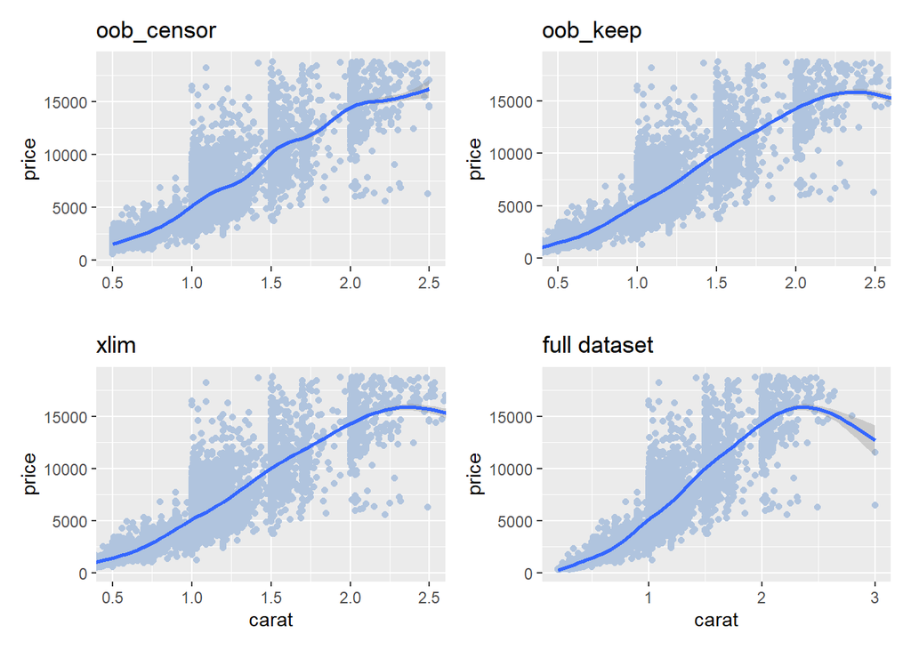

```r
pl_scale_1 <- pl_scale_base + scale_x_continuous(limits = c(0.5, 2.5), oob = scales::oob_censor) + geom_smooth() + labs(title = "oob_censor", x = "")
pl_scale_2 <- pl_scale_base + scale_x_continuous(limits = c(0.5, 2.5), oob = scales::oob_keep) + geom_smooth() + labs(title = "oob_keep", x = "")
pl_scale_3 <- pl_scale_base + coord_cartesian(xlim = c(0.5, 2.5)) + geom_smooth() + labs(title = "xlim")
pl_scale_4 <- pl_scale_base + geom_smooth() + labs(title = "full dataset")

pl_scale_1 + pl_scale_2 + pl_scale_3 + pl_scale_4
```

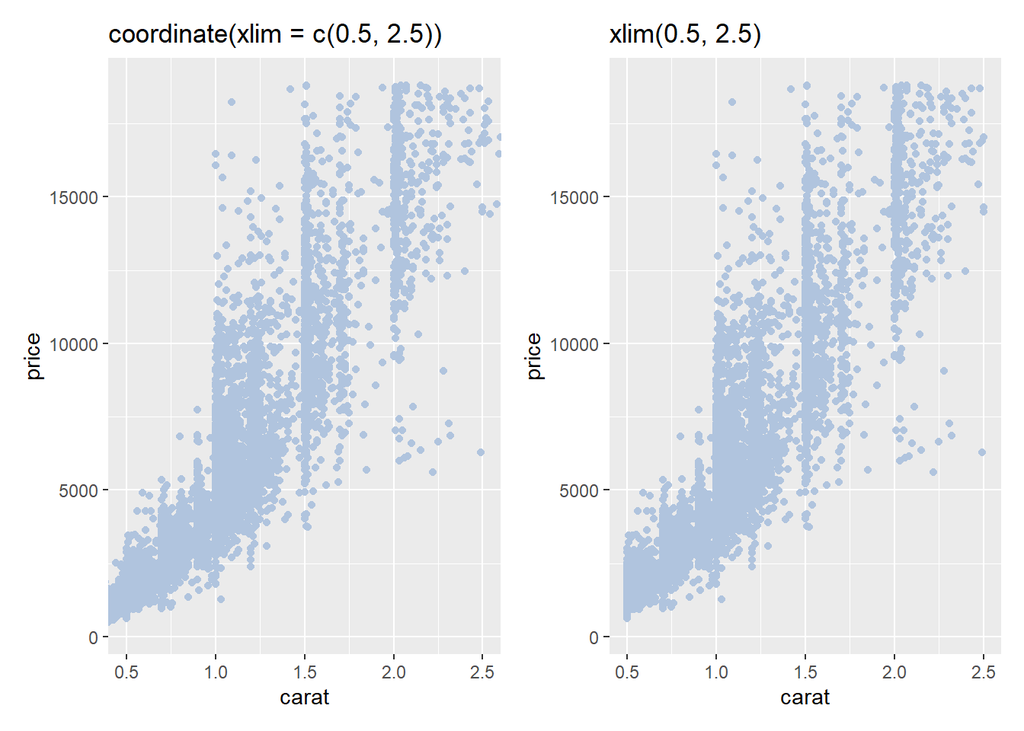

```r
pl_scale_5 <- pl_scale_base + coord_cartesian(xlim = c(0.5, 2.5)) + labs(title = "coordinate(xlim = c(0.5, 2.5))")
pl_scale_6 <- pl_scale_base + xlim(0.5, 2.5) + labs(title = "xlim(0.5, 2.5)")

pl_scale_5 + pl_scale_6
```

You can also extend the range. This might be useful is you want to include 0 as a value or if you want to explicitly show values larger than the maximum. This can be useful if you compare graphs. For instance, let’s first create a plot that uses only prices < 10000 and carat < 3 and compare that plot with the base plot:

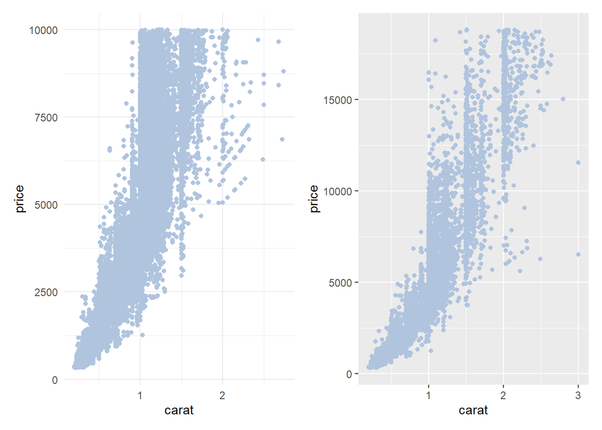

```r
pl_scales_7 <- diamonds |> filter(price < 10000 & carat < 3) |> ggplot(aes(x = carat, y = price)) + geom_point(color = "lightsteelblue") + theme_minimal()

pl_scales_7 + pl_scale_base
```

Notice how the y-axis in both plots differs. In other words, comparing both is difficult. To deal with this, it is useful to expand the limits on the first plot and set them equal to those on the second. To so so, we will set both limits equals to 0 - 20000:

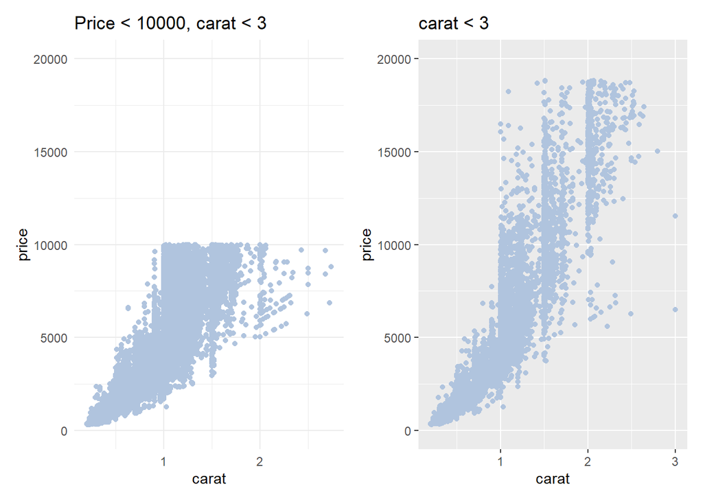

```r
pl_scales_7 <- pl_scales_7 + scale_y_continuous(limits = c(0, 20000)) + labs(title = "Price < 10000, carat < 3")
pl_scale_base2 <- pl_scale_base + scale_y_continuous(limits = c(0, 20000)) + labs(title = "carat < 3")

pl_scales_7 + pl_scale_base2
```

As you can see, it is now easy to compare both plots as the y-axis are similar.

The argument `na.value =` allows you to add a value that will replace missing values.

##### 11.1.1.1.4 Transformations

Recall that we plotted life expectancy at birth and per capita GDP where per capita GDP was shown in a log scale. A log scale is a transformation of the data: the scale used for the axis continues to show per capita GDP, but does so using `log(gdp_capita)`. The argument `transform = "identity"` by default shows the values as they appear in the dataset on the axis. {ggplot2} and {scales} include a wide variaty of ways to transform the variables mapped on the x- and y- axis, e.g. `log10`, `exp`, `log`, `logit`, `sqrt`, `reverse`, `reciprocal`, `boxcox`, `logit`, `probit` … . In addition, {scales} allows you to create your own transformation. Let’s illustrate a transformation using the `log10` transformation. Using `transform = log10` R will compute the log with base 10 of the variable mapped on the axis and show the plot using the log-tranformed variable. However, the labels will show the un-tranformed values. To see how this works, let’s return to the life expectancy dataset.

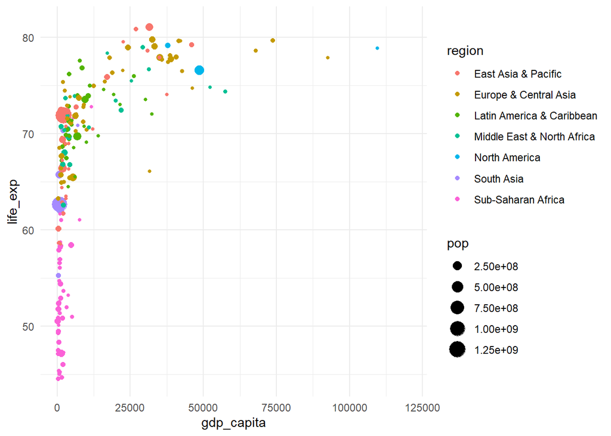

```r
life_df |> filter(date == 2000) |>
  ggplot(aes(x = gdp_capita, y = life_exp, color = region, size = pop)) +
  geom_point() +
  theme_minimal()
```

Here, the variable `gdp_capita` is showing a very wide range: the richest economy is more than 100 times richer than the poorest one. A log10 transformation can reduce this range: To show this, log(100,000) = 5 and the log(10) = 1. In other words using a log transformation reduces the range from 1 in 10,000 to 1 in 5. One way to do so would be to calculate the log of the variables in the dataset and use these to plot:

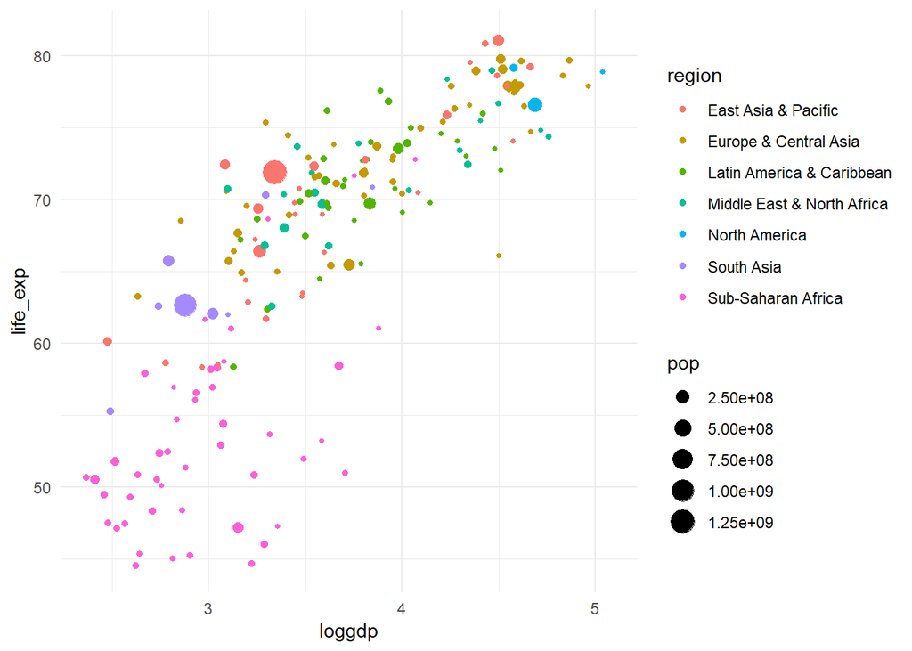

```r
life_df |> filter(date == 2000) |> mutate(loggdp = log(gdp_capita, base = 10)) |>
  ggplot(aes(x = loggdp, y = life_exp, color = region, size = pop)) +
  geom_point() +
  theme_minimal()
```

However, as you can see in the graph: the labels on the horizontal axis are now 3, 4, 5, … . These are not informative in terms of the level of per capita GDP shown. You first have to calculate the power 10, to see what level of per capita GDP they represent. You could deal with that using `breaks` and `labels` in `scale_x_continuous()`:

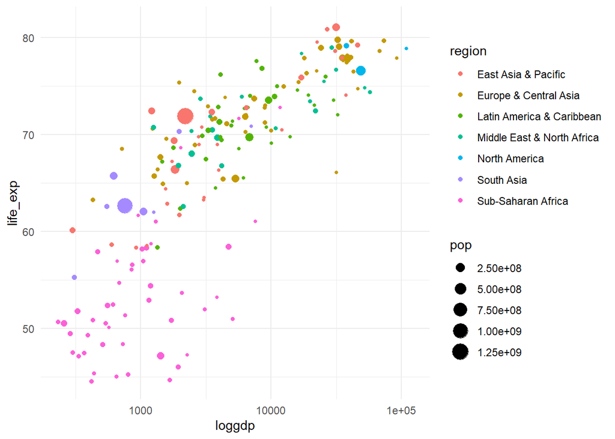

```r
life_df |> filter(date == 2000) |> mutate(loggdp = log(gdp_capita, base = 10)) |>
  ggplot(aes(x = loggdp, y = life_exp, color = region, size = pop)) +
  geom_point() +
  scale_x_continuous(breaks = c(3, 4, 5), labels = 10^(3:5)) +
  theme_minimal()
```

However, as you can see, this takes a lot of code. This is where the transformations enter. Using `transform = "log10"` in `scale_x_continuous` (or `scale_y_continuous`) `ggplot()` will transform the data and does not require a prior `mutate`:

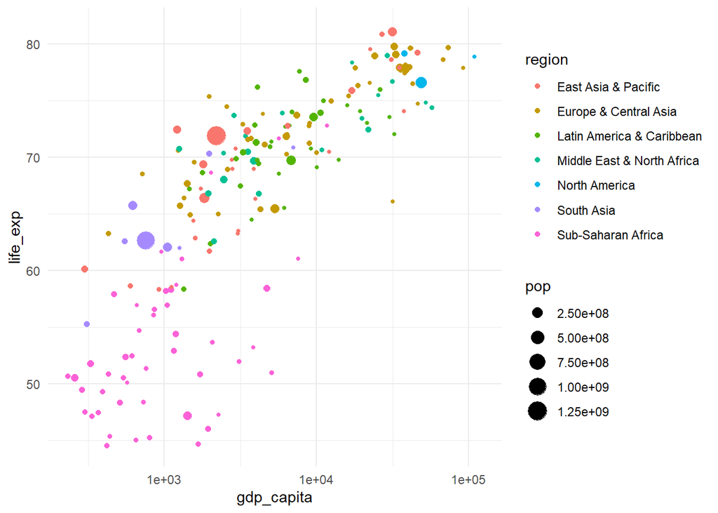

```r
life_df |> filter(date == 2000) |>
  ggplot(aes(x = gdp_capita, y = life_exp, color = region, size = pop)) +
  geom_point() +
  scale_x_continuous(transform = "log10") +
  theme_minimal()
```

You can now set the breaks and labels, and the plot is finished. Note that in this case, you can refer to the breaks using values in your dataset.

[figure not shown]

```r
life_df |> filter(date == 2000) |>
  ggplot(aes(x = gdp_capita, y = life_exp, color = region, size = pop)) +
  scale_x_continuous(
    transform = "log",
    breaks = c(100, 1000, 10000, 100000),
    labels = scales::label_currency(prefix = "$")) +
  theme_minimal()
```

Using `tranform = "reverse"` you change the order of the axis. With this transformation, the values on the x-axis are shown, moving from the left to right, from large to small (with the smallest the most right position on the x-axis) and, on the y-axis and moving from bottom to top, from high to low (with the lowest value the highest on the y-axis) Reversing the order on the y-axis, shows lower levels of life expectancy at birth higher up the axis:

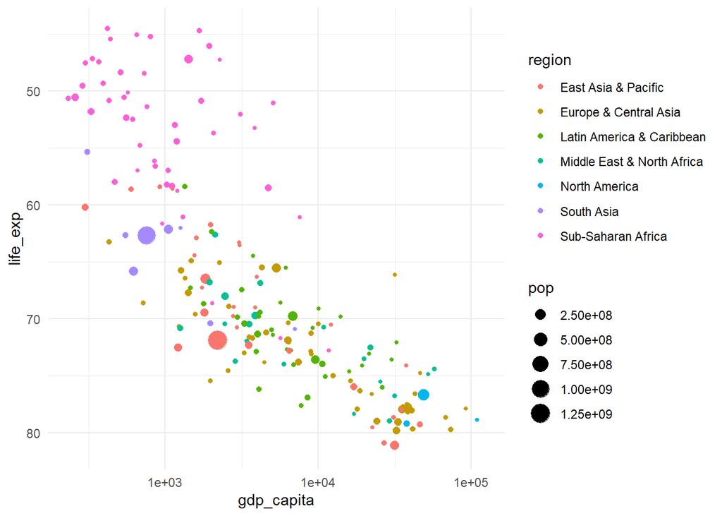

```r
life_df |> filter(date == 2000) |>
  ggplot(aes(x = gdp_capita, y = life_exp, color = region, size = pop)) +
  geom_point() +
  scale_x_continuous(transform = "log10") +
  scale_y_continuous(transform = "reverse") +
  theme_minimal()
```

This transformation can be useful is you have two plots side by side. The first measures something: high is good (life expectancy at birth), the second measures something: high is bad (infant mortality rates). If you reverse the axis for the latter, it is shown as high is good and low is bad. Doing so, makes it often easier to compare charts.

For some of these transformation, you can use specific scale functions: `scale_x/y_log10`, `scale_x/y_reverse` and `scale_x/y_sqrt`. Doing so, you can use `scale_x/y_log10()` as a substitute for `scale_x/y_continuous(transform = "log10")` or `scale_y/Y_reverse()` as a substitute for `scale_x/y_continuous(transform = "reverse")`. {scales} includes many other transformations.

##### 11.1.1.1.5 Guide, position and secundary axis

The `guide =` argument allows you to specify the legend. Here, for numeric continuous variables mapped on the x- and y-axis this is less relevant. As you usually wouldn’t include a legend for these axis: the title and labels on the axis are (or should be) sufficient as a guide. The `position =` argument determines where the axis will be shown: for the vertical axis: left or right and for the horizontal axis: bottom or top. For the x-axis, the default is “bottom” and for the y-axis, the default is left. Changing this into “top” and/or “right” changes this:

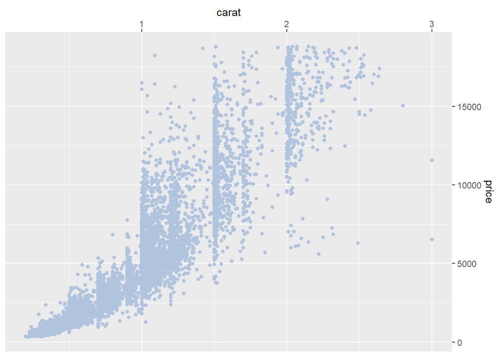

```r
pl_scale_base +
  scale_x_continuous(position = "top") +
  scale_y_continuous(position = "right")
```

You can add a secondary axis to your plot. In that way, you have two axis. `dup_axis()` copies the primary x- or y-axis. `sec_axis()` allows for a monotonic transformation from the values on the primary axis to the values on the secondary axis. Using `dup_axis()` you can add a name, but the breaks and labels are those on the primary axis. For `sec_axis()` you can also include a monotonic transformation (i.e. a one-on-one transformation with the values on the primary axis.) To illustrate the first, let’s add a duplicate secondary vertical axis to the diamonds plot:

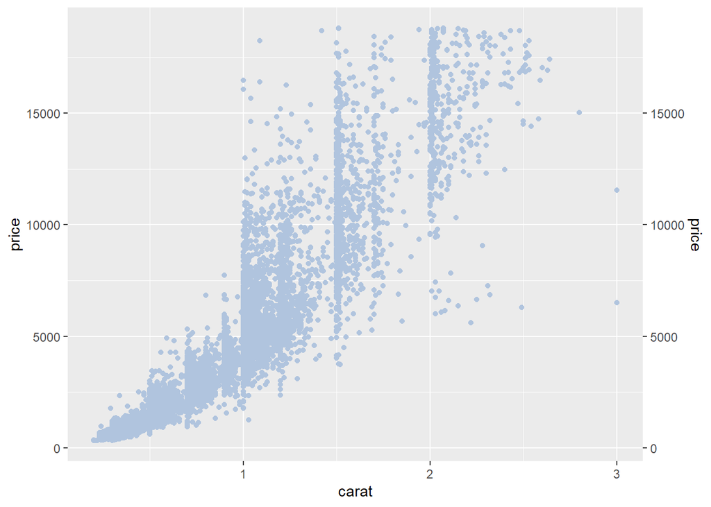

```r
pl_scale_base + scale_y_continuous(sec.axis = dup_axis())
```

To remove the label from the secondary axis, you can include `name = NULL`. Using `breaks =` or `labels =`, you can also change the breaks and labels on the second vertical axis. To add these, you can use similar methods than those for the primary axis:

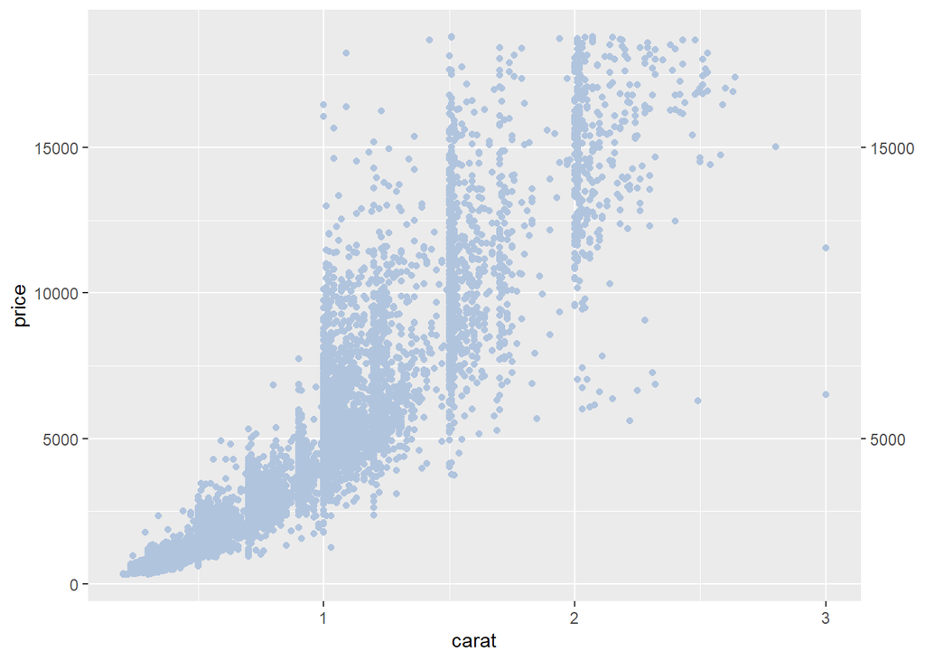

```r
pl_scale_base +
  scale_y_continuous(
    sec.axis = dup_axis(
      name = NULL,
      breaks = c(5000, 15000),
      labels = seq(5000, 15000, by = 10000)))
```

Using `dus_axis()` you can highlight other value ranges on the secondary axis than those on the primary axis. In the plot, observations on the left are relatively low on price, while those on the right are relatively high. You can stress this in the plot by setting different breaks for both axis: for the primary axis, you include more breaks and labels on the lower and of price while you add more breaks on labels on the secondary axis at higher price ranges:

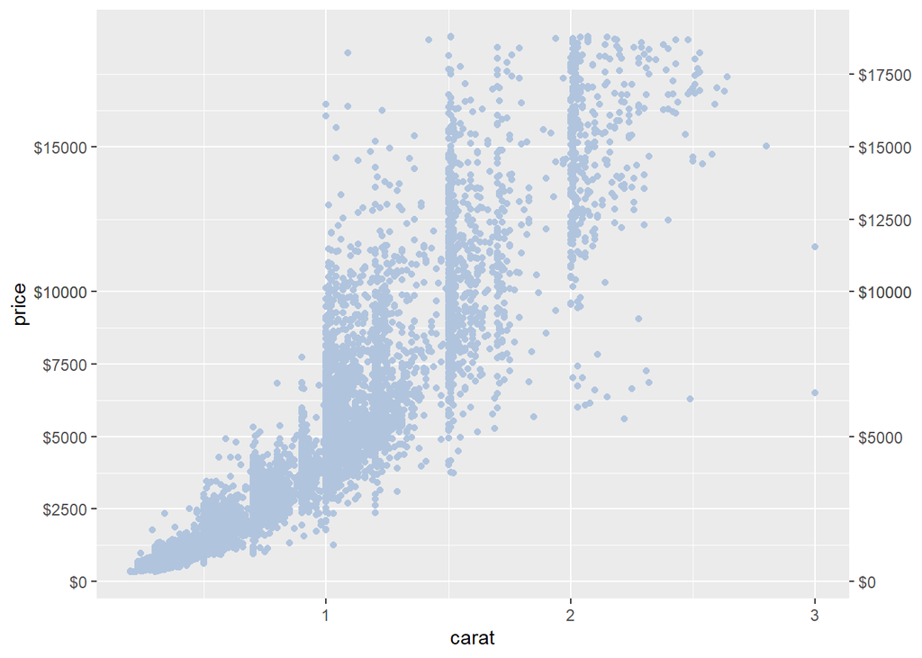

```r
pl_scale_base +
  scale_y_continuous(
    breaks = c(seq(0, 10000, by = 2500), seq(10000, 20000, by = 5000)),
    labels = paste("$", c(seq(0, 10000, by = 2500), seq(10000, 20000, by = 5000)), sep = ""),
    sec.axis = dup_axis(
      name = NULL,
      breaks = c(seq(0, 10000, by = 5000), seq(10000, 20000, by = 2500)),
      labels = paste("$", c(seq(0, 10000, by = 5000), seq(10000, 20000, by = 2500)), sep = "")))
```

Using `sec_axis()` you can add a secondary axis with a different scale. However, the scale of the secondary axis must be a monotonic transformation of the first. This allows you to show three variables on three axis: one variable mapped on the x-axis, one on the primary y-axis and one on the secondary y-axis. Although this is something that is often done, it is not recommended. A “double” line graph for instance, with one variable mapped on the primary vertical axis and another on the secondary vertical axis suggests correlation, even if the correlation is completely spurious. To illustrate, consider Figure 11.2, which was taken from [Tyler Vigen] (https://tylervigen.com/spurious-correlations)] and shows the distance between the planet Neptune and the earth and the number of burglaries in Kansas. The plot suggests that we should find a way to get Neptune as close as possible to the earth. Tyler Vigen’s site includes many more of these examples and often includes a GenIA generated motivation why these correlations might exist.

Figure 11.2: Does Neptune cause burglaries in Kansas?

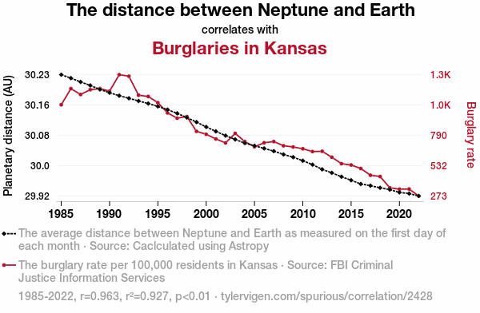

To show correlation, you can use other geometries, e.g. point geometries (where you maps one variable on the horizontal axis and another on the vertical one, Figure 10.1), a path geometry to show co-movement, … .

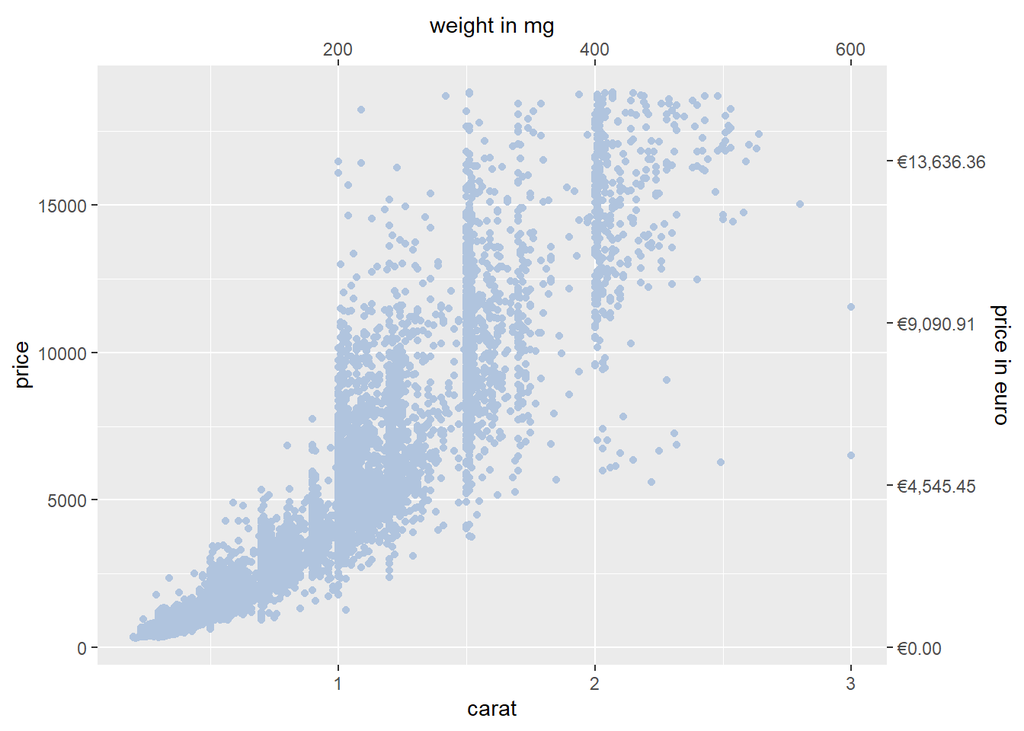

```r
pl_scale_base +
  scale_x_continuous(
    sec.axis = sec_axis(
      transform = ~. * 200,
      name = "weight in mg")) +
  scale_y_continuous(
    sec.axis = sec_axis(
      transform = ~. /1.10,
      name = "price in euro",
      labels = scales::label_currency(
        scale = 1/1.10,
        prefix = "€")))
```

A secondary axis is sometimes used to add two variables with different measurements on the y-axis. One variable is then mapped on the left axis, the other on the right axis. Both are shown using an e.g. line geometry. Doing so, it is easy to spot e.g. similar behavior (e.g. both decline in a recession and rise as growth picks up). In general, it is a good idea to first ask is this is the only way to show this type of co-movement. In many cases, scaling both variables or using an index to show their value would allow the same outcome. Using an index for instance, the values are re-scaled by dividing all values by the value of the same variable in a base year

$$\frac{x_t}{x_{t=base}}*100$$

Doing so, both series are re-scaled and will equal 100 in the base year and show their cumulative change in time: a level of 112 shows that the variable has risen 12% relative to the base year. This line will show similar behaviour as the unscales line but wouldn’t require a secondary axis.

#### 11.1.1.2 `scale_x/y_date()` and `scale_x/y_datetime()` and `scale_x/y_datetime()`

Recall from Chapter 3 that date and time variables are continuous numeric variables using the number of days since January 1st 1970 of the number of seconds since midnight that day. Date/time variables are often used in data science: each transaction you do in a store has a date/time stamp, sales data is available per day or per month and stock market data is usually available at intervals measured in (parts of) seconds. There are three date/time scale functions: `_date()` for class data, `_datatime()` for POSIXct and `_time()` for data measured in hours, minutes and seconds. Here, I’ll use the `scale_x/y_datetime()` and focus on the difference with the previous scale. The arguments of this function are

```r
scale_x_datetime(
  name = waiver(),
  breaks = waiver(),
  date_breaks = waiver(),
  labels = waiver(),
  date_labels = waiver(),
  minor_breaks = waiver(),
  date_minor_breaks = waiver(),
  timezone = NULL,
  limits = NULL,
  expand = waiver(),
  oob = censor,
  guide = waiver(),
  position = "bottom",
  sec.axis = waiver()
)
```

There are a couple of arguments that are specific for POSIXct variables: `date_breaks`, `date_labels`, `data_minor_breaks` and `timezone`. The other arguments are similar to those for the `scale_x/y_continuous` function. However, they may have to be adapted to the specific case of date/time variables. `breaks =` for instance is similar to the equivalent argument in `scale_x/y_continuous`: you can define breaks using a vector or a function. Here, given that the data are POSIXct, the vector should be a date/time vector and the function should return a date/time variable, e.g. `seq.Date()` or `seq.POSIXt`. The same holds for e.g. `labels` or `minor_breaks()`.

The function also includes a number of arguments specific to the date/time format. `date_breaks` allows to specify an interval using “sec”, “min”, “hour”, “day”, “week”, “month” or “year” (optionally followed by an s, e.g. “hours”, “days”). The the notation follows “n hours”, “n days”, … . For instance, using `date_breaks = "1 month"` will return major break points that are one month apart. In addition you can use {scales} to add specific date/time break functions. All these follow the `breaks` argument:

- `scales::breaks_width(width, offset = 0)` with `width` the width between major breaks using “n hours” and `offset` if you don’t want breaks to start at e.g. January 1st but at e.g. seven days later (`offset = "7 days"`)
- `scales::breaks_pretty(n = 5)` to set `n` breaks for date/time variables and works in a similar way to `scales::extended_breaks(n = )` for continuous variables
- `scales::timespan(unit = c("secs", "mins", "hours, "days", "weeks"), n = 5)` to set breaks using time intervals for date/time variables where `unit` is used to interpret the unit of the timespan (e.g. hours) and `n` is the desired number of breaks.

Note that `date_breaks = "1 month"` is equal to using `breaks = scales::breaks_width("1 month")` (note that the first argument is `date_breaks` and the second is `breaks`. You can define minor breaks in a similar way, although the minor break needs to fit within the major breaks (e.g. weeks fit in a month).

Using `date_labels`, you can add labels to and use the notation referred to in Table 3.1 and Table 3.2. In other words, `date_labels = "%Y"` will show 4-digit years as labels, `date_labels = "%b"` abbreviated months, … In addition, using “”, the notation for “next line” in regular expressions, you can show e.g. months above years. For instance, using `date_labels = "%B\n%Y"` will show the labels on two rows: the first the full name of the month and on the second row the 4-digit year. Using `labels` you have to add a character vector with labels or a function that generates these labels (`paste`, `paste0`, … ). In addition you can use {scales} functions with the `labels` argument:

- `scales:: label_date(format = "%Y-%m-%d", tz = "UTC" , locale = )` to set the format, time zone and locale (by default the current locale, use `locale = Sys.setlocale("LC_TIME", "English")` to show months and days in English)
- `scales::label_date_short(format = c("%Y", "%b", "%d", "%H:%M"), sep = "\n")` to generate labels on two rows with the first label the e.g. the day or the month and the second the month or the year where the second row is only added on the first and last day of the month or month of the year
- `scales::label_time(format = "%H:%M:%S", tz = "UTC", locale = NULL)` to set the format for time, including time zone and locale
- `scales::label_timespan(unit = c("secs", "mins", "hours", "days", "weeks"), space = FALSE, ...)` the set a timespan in seconds, minutes, hours, … . You can add a space before the time unit and … allowing you to specify the e.g. accuracy.

If you specify `date_breaks`, `date_labels` or `date_minor_breaks` as well as `breaks` or `labels` or `minor_breaks` the former will be used.

To illustrate, we’ll use the nycflights dataset which you can import from the `data > raw` directory as `nycflights.csv`. This dataset is the result of the mutations completed in the “your turn” in Chapter 8.

```r
nycflights <- read_csv(here::here("data", "raw", "nycflights.csv"))
```

We will show a plot with the number of flights per day. To do so, we only use the flights with all available data. Recall that the variable `status` records if an observation has missing data, or not. Using `status == complete` we filter the data. Using {lubridate}’s `floor_date` (see Chapter 3), we round the scheduled departure time in POSIXct to the day. Using `summarize`, we can then calculate the total flights per day. To limit the sample, we use `slice_sample(prop = 0.10)` and use 10% of the observations. Although we could pipe the resulting data frame in `ggplot`, we wil first assign it to `nyc_day`:

```r
nyc_day <- nycflights |>
  filter(status == "complete") |>
  slice_sample(prop = 0.10) |>
  mutate(round_date = floor_date(sched_dep_hhmm, unit = "day")) |>
  group_by(round_date) |>
  summarize(n_flights = n()) |>
  ungroup()
```

Using a line geometry with the rounded data mapped on the x-axis and the number of flights on the y-axis and accepting all default values, `ggplot()` shows this graph:

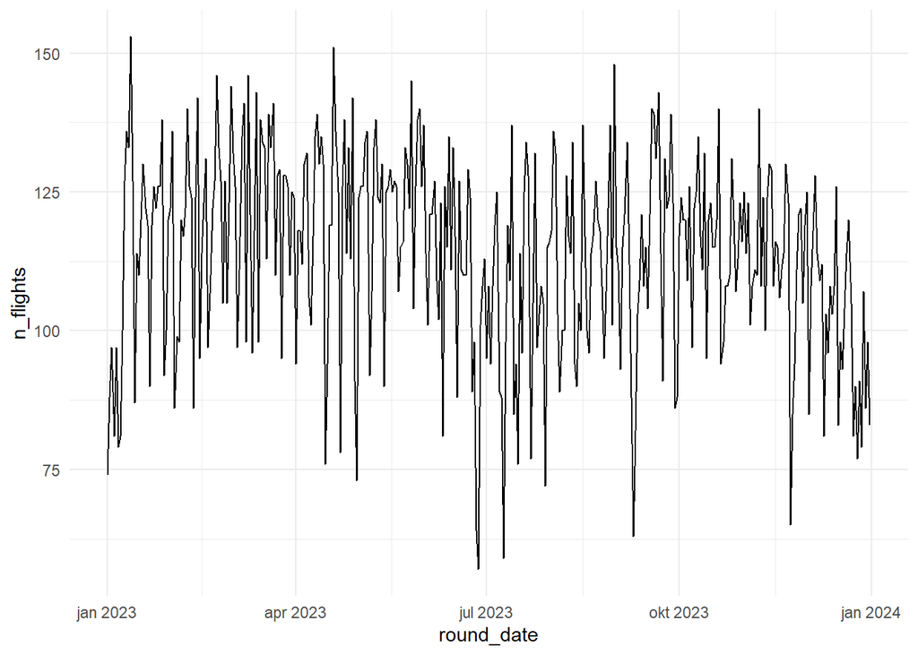

```r
nyc_day |>
  ggplot(aes(x = round_date, y = n_flights)) +
  geom_line() +
  theme_minimal()
```

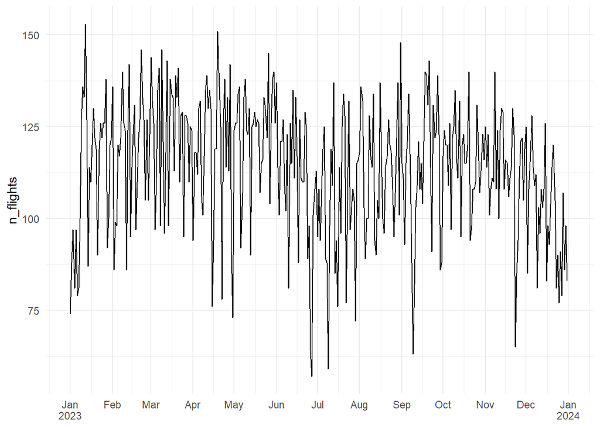

```r
nyc_day |>
  ggplot(aes(x = round_date, y = n_flights)) +
  geom_line() +
  scale_x_datetime(
    name = NULL,
    breaks = scales::breaks_width("1 month"),
    labels = scales::label_date_short(format = c("%Y", "%b", locale = Sys.setlocale("LC_TIME", "English")), sep = "\n"),
    limits = c(as.POSIXct("2023-01-01 00:00:00", tz = "UTC"), as.POSIXct("2023-12-31 23:59:59", tz = "UTC"))) +
  theme_minimal()
```

As you can see, the every major break now shows the month. The first and last month also include the year. Doing so, it is easy to read from the axis when date/time variables change from one year to the other, from one month to the other, … . Let’s change the breaks using `date_breaks` and set labels using `date_labels`. We’ll set major breaks per 3 months, add minor breaks per month and show labels using the full name of the month on the first row and the 2-digit year on the second. In addition, we will add a title to the y-axis and remove minor breaks from that axis:

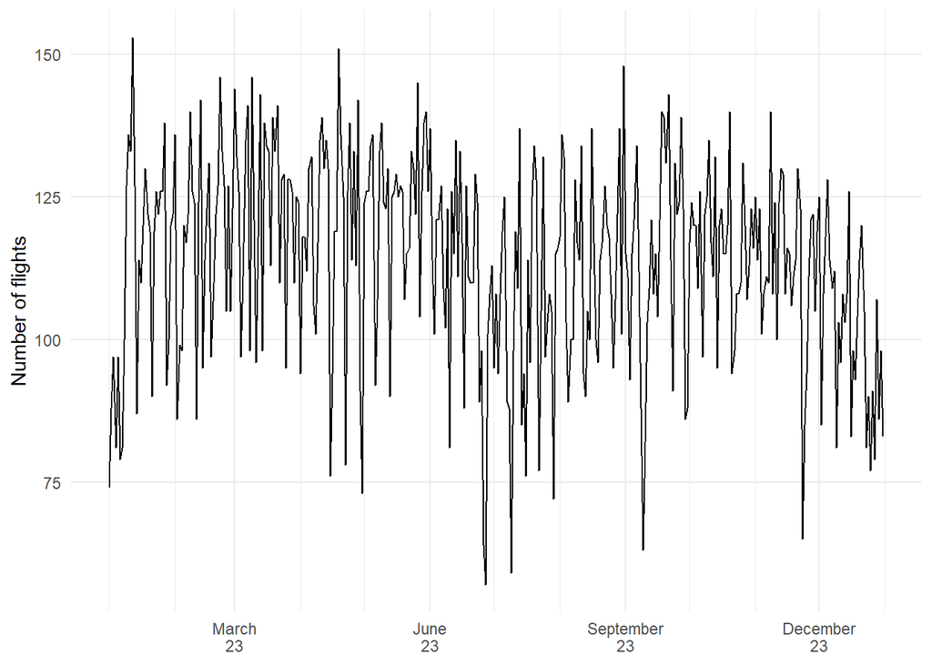

```r
nyc_day |>
  ggplot(aes(x = round_date, y = n_flights)) +
  geom_line() +
  scale_x_datetime(
    name = NULL,
    date_breaks = "3 months",
    date_labels = "%B\n%y",
    date_minor_breaks = "1 month") +
  scale_y_continuous(
    name = "Number of flights",
    minor_breaks = NULL) +
  theme_minimal()
```

Let’s now focus on 1 day and show the number of flights on July 4, 2023 per hour. To select this day, we use `month()` and `mday()` from {lubridate}:

```r
nyc_july4 <- nycflights |>
  filter(status == "complete" & month(sched_dep_hhmm) == 7 & mday(sched_dep_hhmm) == 4) |>
  mutate(round_date = floor_date(sched_dep_hhmm, unit = "hour")) |>
  group_by(round_date) |>
  summarize(n_flights = n()) |>
  ungroup()
```